# 經濟壓力與抗憂鬱藥物使用的相關性

B0902063 B0603176

1/5/2022

# 經濟壓力與抗憂鬱藥物使用的相關性

## 壹、研究動機

憂鬱症在台灣是一種相當普遍的精神疾病，隨著社會經濟的發展，人數似乎有逐年攀升的趨勢。而新聞中經常報導現代人龐大的經濟壓力（如：高房價、高物價）導致的憂鬱與困境，因此，在本研究中，我們以消費者物價指數和房價負擔能力作為民生經濟的指標，進行經濟壓力與憂慮症藥物使用的關聯性分析。

## 貳、研究方法

- 下載官方資料並整裡出所需數據
- 通過R本身內建函式庫與安裝ggplot2, rgdal, tmap等套件以進行統計分析
- 繪製直方圖、點狀圖與相關係數的計算並將統計資料結合台灣地圖使資料可視化

## 參、資料統計與結果分析

### 100~109年度使用抗憂慮劑之病人數10年統計

```
##     年分 使用抗憂慮劑之病人數10年統計
## 1  100年                       944278
## 2  101年                       983490
## 3  102年                      1141151
## 4  103年                      1165942
## 5  104年                      1194395
## 6  105年                      1212659
## 7  106年                      1273561
## 8  107年                      1330204
## 9  108年                      1397197
## 10 109年                      1468716
```

```
## 'data.frame':    10 obs. of  2 variables:
##  $ 年分                        : chr  "100年" "101年" "102年" "103年" ...
##  $ 使用抗憂慮劑之病人數10年統計: int  944278 983490 1141151 1165942 1194395 1212659 1273561 1330204 1397197 1468716
```

[output not shown]

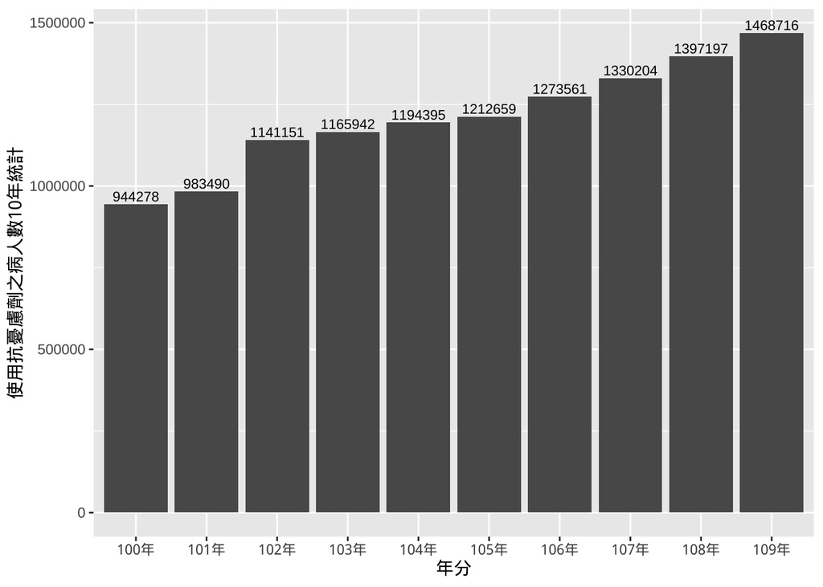

### 100~109消費者物價指數

```
##    年分 消費者物價指數
## 1   100          95.15
## 2   101          96.99
## 3   102          97.76
## 4   103          98.93
## 5   104          98.63
## 6   105         100.00
## 7   106         100.62
## 8   107         101.98
## 9   108         102.55
## 10  109         102.31
```

```
## 'data.frame':    10 obs. of  2 variables:
##  $ 年分          : int  100 101 102 103 104 105 106 107 108 109
##  $ 消費者物價指數: num  95.2 97 97.8 98.9 98.6 ...
```

[output not shown]

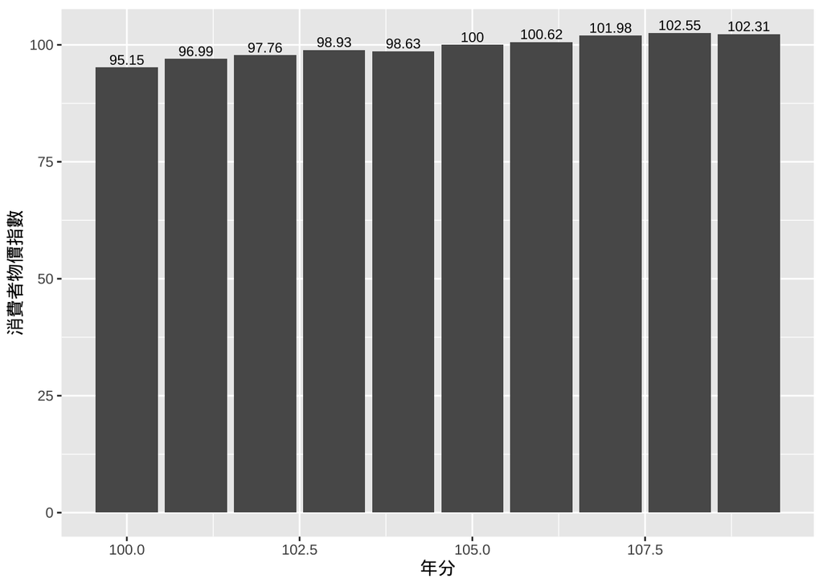

### 100~109憂慮症用藥人數與消費者物價指數的關聯性

```
## [1] 0.9663229
```

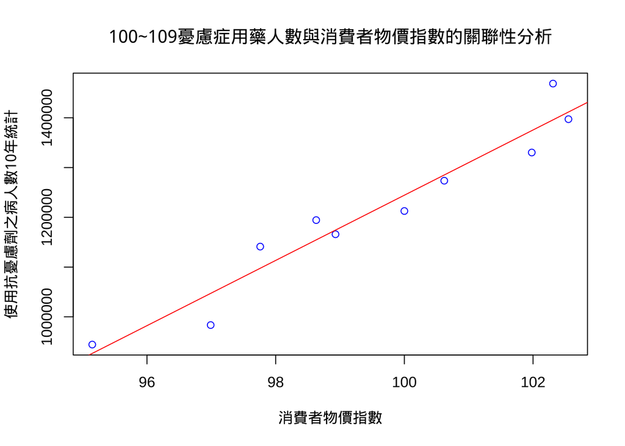

### 台灣抗憂鬱藥物使用之縣市比例圖

```
##    各縣市抗憂鬱藥物使用人數統計   X105   X106   X107   X108   X109
## 1                        新北市 162989 173431 181146 191679 204554
## 2                        臺北市 199466 206280 217632 226235 234573
## 3                        基隆市  19793  20849  21215  21986  22162
## 4                        宜蘭縣  24991  26572  27254  27610  27824
## 5                        桃園市 104821 113749 119837 127487 135022
## 6                        新竹市  25666  26645  28544  31258  34739
## 7                        新竹縣  18271  19321  20147  23912  27222
## 8                        苗栗縣  20863  21787  22422  23078  23797
## 9                        臺中市 163980 171964 179930 189392 199089
## 10                       彰化縣  67485  70788  72725  76513  79304
## 11                       南投縣  26339  27097  28124  29086  29761
## 12                       臺南市  99810 105166 110830 116502 123647
## 13                       嘉義市  39833  40838  42009  43466  43906
## 14                       雲林縣  36936  38704  39942  41631  41916
## 15                       嘉義縣  20465  21414  20978  21623  22941
## 16                       高雄市 162037 172618 182302 189604 203872
## 17                       屏東縣  32723  33385  35020  37781  38956
## 18                       花蓮縣  21948  22531  22737  23847  24829
## 19                       臺東縣  11925  11344  10979  11903  12234
```

```
## 'data.frame':    19 obs. of  6 variables:
##  $ 各縣市抗憂鬱藥物使用人數統計: chr  "新北市" "臺北市" "基隆市" "宜蘭縣" ...
##  $ X105                        : int  162989 199466 19793 24991 104821 25666 18271 20863 163980 67485 ...
##  $ X106                        : int  173431 206280 20849 26572 113749 26645 19321 21787 171964 70788 ...
##  $ X107                        : int  181146 217632 21215 27254 119837 28544 20147 22422 179930 72725 ...
##  $ X108                        : int  191679 226235 21986 27610 127487 31258 23912 23078 189392 76513 ...
##  $ X109                        : int  204554 234573 22162 27824 135022 34739 27222 23797 199089 79304 ...
```

```
##  [1] 182759.8 216837.2  21201.0  26850.2 120183.2  29370.4  21774.6  22389.4
##  [9] 180871.0  73363.0  28081.4 111191.0  42010.4  39825.8  21484.2 182086.6
## [17]  35573.0  23178.4  11677.0
```

```
##    各縣市抗憂鬱藥物使用人數統計   X105   X106   X107   X108   X109
## 1                        新北市 162989 173431 181146 191679 204554
## 2                        臺北市 199466 206280 217632 226235 234573
## 3                        基隆市  19793  20849  21215  21986  22162
## 4                        宜蘭縣  24991  26572  27254  27610  27824
## 5                        桃園市 104821 113749 119837 127487 135022
## 6                        新竹市  25666  26645  28544  31258  34739
## 7                        新竹縣  18271  19321  20147  23912  27222
## 8                        苗栗縣  20863  21787  22422  23078  23797
## 9                        臺中市 163980 171964 179930 189392 199089
## 10                       彰化縣  67485  70788  72725  76513  79304
## 11                       南投縣  26339  27097  28124  29086  29761
## 12                       臺南市  99810 105166 110830 116502 123647
## 13                       嘉義市  39833  40838  42009  43466  43906
## 14                       雲林縣  36936  38704  39942  41631  41916
```

[output cut: 25 more lines]

```
## [1] 1390708
```

```
##  [1] 0.131414972 0.155918613 0.015244757 0.019306862 0.086418741 0.021119033
##  [7] 0.015657209 0.016099286 0.130056814 0.052752282 0.020192167 0.079952824
## [13] 0.030207932 0.028637077 0.015448395 0.130930902 0.025579065 0.016666624
## [19] 0.008396445
```

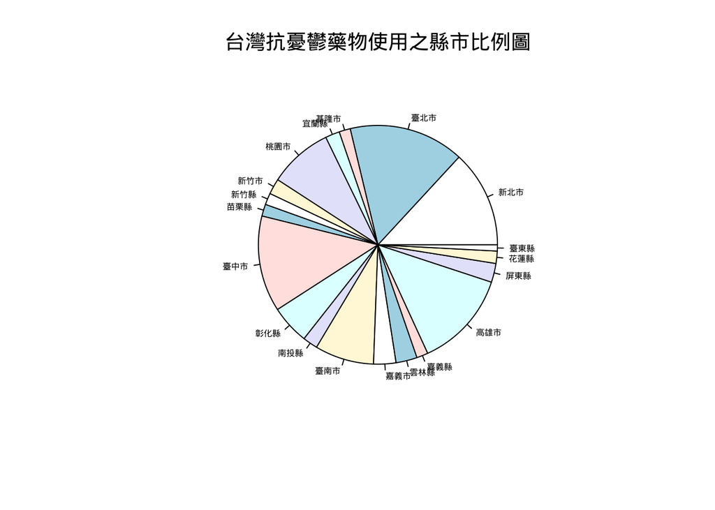

```
##      city        rate
## 1  新北市 0.131414972
## 2  臺北市 0.155918613
## 3  基隆市 0.015244757
## 4  宜蘭縣 0.019306862
## 5  桃園市 0.086418741
## 6  新竹市 0.021119033
## 7  新竹縣 0.015657209
## 8  苗栗縣 0.016099286
## 9  臺中市 0.130056814
## 10 彰化縣 0.052752282
## 11 南投縣 0.020192167
## 12 臺南市 0.079952824
## 13 嘉義市 0.030207932
## 14 雲林縣 0.028637077
## 15 嘉義縣 0.015448395
## 16 高雄市 0.130930902
## 17 屏東縣 0.025579065
## 18 花蓮縣 0.016666624
## 19 臺東縣 0.008396445
```

[output not shown]

```
## class       : SpatialPolygonsDataFrame
## features    : 19
## extent      : 116.71, 122.1085, 20.6975, 25.63431  (xmin, xmax, ymin, ymax)
## crs         : +proj=longlat +datum=WGS84 +no_defs
## variables   : 13
## names       : GID_0, NAME_0,   GID_1,    NAME_1, NL_NAME_1,     GID_2,   NAME_2,     VARNAME_2, NL_NAME_2,    TYPE_2,            ENGTYPE_2, CC_2,   HASC_2
## min values  :   TWN, Taiwan, TWN.2_1, Kaohsiung,      高雄, TWN.2.1_1, Changhua,  Gāoxióng Shì,    高雄市,       Shì,               County,   NA, TW.KH.KS
## max values  :   TWN, Taiwan, TWN.7_1,    Taiwan,      新北, TWN.7.9_1,    Yulin, Zhānghuà Xiàn,    彰化縣, Zhíxiáshì, Special Municipality,   NA, TW.TP.TC
```

```
##   zh_NAME GID_0 NAME_0   GID_1     NAME_1 NL_NAME_1     GID_2     NAME_2
## 1  高雄市   TWN Taiwan TWN.2_1  Kaohsiung      高雄 TWN.2.1_1  Kaohsiung
## 2  新北市   TWN Taiwan TWN.3_1 New Taipei      新北 TWN.3.1_1 New Taipei
## 3  臺中市   TWN Taiwan TWN.4_1   Taichung      台中 TWN.4.1_1   Taichung
## 4  臺南市   TWN Taiwan TWN.5_1     Tainan      台南 TWN.5.1_1     Tainan
## 5  臺北市   TWN Taiwan TWN.6_1     Taipei      台北 TWN.6.1_1     Taipei
## 6  彰化縣   TWN Taiwan TWN.7_1     Taiwan      台灣 TWN.7.1_1   Changhua
##       VARNAME_2 NL_NAME_2    TYPE_2            ENGTYPE_2 CC_2   HASC_2
## 1  Gāoxióng Shì    高雄市 Zhíxiáshì Special Municipality <NA> TW.KH.KS
## 2    Xīnběi Shì    新北市 Zhíxiáshì Special Municipality <NA> TW.NT.TP
## 3 Taichung City      台中 Zhíxiáshì Special Municipality <NA> TW.TG.TU
## 4   Tainan City      台南 Zhíxiáshì Special Municipality <NA> TW.TN.TI
## 5    Táiběi Shì    台北市 Zhíxiáshì Special Municipality <NA> TW.TP.TC
## 6 Zhānghuà Xiàn    彰化縣      Xiàn               County <NA> TW.TA.CG
##         rate
## 1 0.13093090
## 2 0.13141497
## 3 0.13005681
## 4 0.07995282
## 5 0.15591861
## 6 0.05275228
```

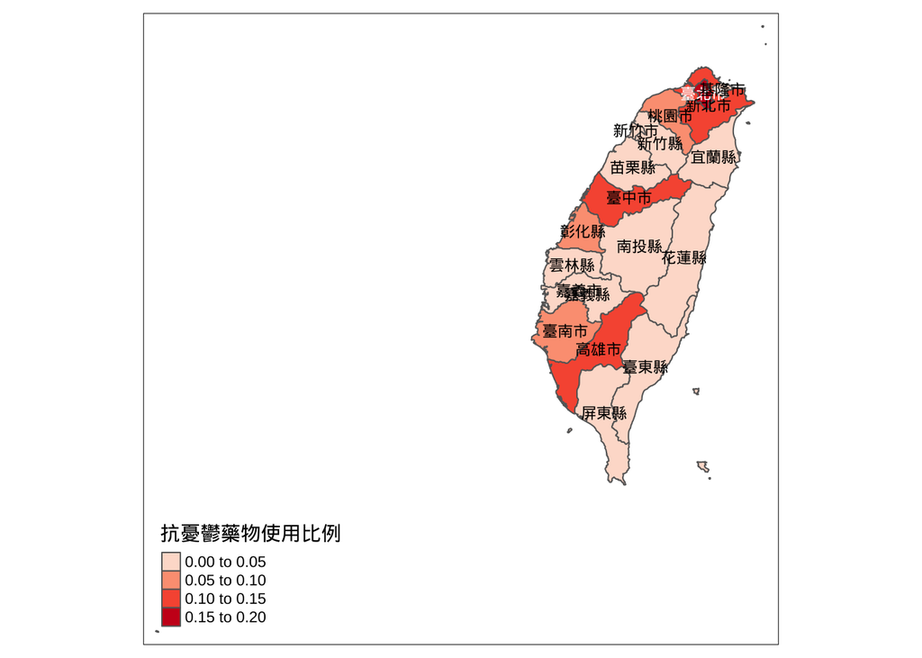

### 各縣市房價負擔能力與憂鬱藥物使用的關聯

```
##    房價負擔能力表.3季..貸款負擔率...  X105  X106  X107  X108  X109
## 1                             新北市 52.33 51.21 49.79 47.80 48.63
## 2                             臺北市 63.71 62.08 57.70 56.28 61.14
## 3                             基隆市 22.68 24.16 23.17 24.49 22.46
## 4                             宜蘭縣 33.90 34.45 32.68 31.71 33.98
## 5                             桃園市 35.00 33.76 30.79 29.67 31.72
## 6                             新竹市 33.28 33.06 30.93 28.07 29.62
## 7                             新竹縣 35.91 35.82 32.89 33.22 33.40
## 8                             苗栗縣 30.39 33.10 33.28 30.87 29.70
## 9                             臺中市 38.79 38.70 37.97 38.49 39.91
## 10                            彰化縣 35.44 36.05 33.58 31.97 36.12
## 11                            南投縣 31.57 30.89 34.59 36.25 31.99
## 12                            臺南市 30.64 30.13 28.00 28.41 30.15
## 13                            嘉義市 23.56 24.15 21.18 22.32 21.47
## 14                            雲林縣 28.33 29.24 26.98 25.51 27.98
## 15                            嘉義縣 23.23 22.69 23.51 22.63 23.46
## 16                            高雄市 35.48 34.15 30.97 29.06 30.58
## 17                            屏東縣 24.22 23.57 22.62 22.03 23.34
## 18                            花蓮縣 32.71 31.48 37.13 32.02 34.35
## 19                            臺東縣 27.43 29.09 29.94 32.81 31.79
```

```
## 'data.frame':    19 obs. of  6 variables:
##  $ 房價負擔能力表.3季..貸款負擔率...: chr  "新北市" "臺北市" "基隆市" "宜蘭縣" ...
##  $ X105                             : num  52.3 63.7 22.7 33.9 35 ...
##  $ X106                             : num  51.2 62.1 24.2 34.5 33.8 ...
##  $ X107                             : num  49.8 57.7 23.2 32.7 30.8 ...
##  $ X108                             : num  47.8 56.3 24.5 31.7 29.7 ...
##  $ X109                             : num  48.6 61.1 22.5 34 31.7 ...
```

```
##  [1] 49.952 60.182 23.392 33.344 32.188 30.992 34.248 31.468 38.772 34.632
## [11] 33.058 29.466 22.536 27.608 23.104 32.048 23.156 33.538 30.212
```

```
##    房價負擔能力表.3季..貸款負擔率...  X105  X106  X107  X108  X109
## 1                             新北市 52.33 51.21 49.79 47.80 48.63
## 2                             臺北市 63.71 62.08 57.70 56.28 61.14
## 3                             基隆市 22.68 24.16 23.17 24.49 22.46
## 4                             宜蘭縣 33.90 34.45 32.68 31.71 33.98
## 5                             桃園市 35.00 33.76 30.79 29.67 31.72
## 6                             新竹市 33.28 33.06 30.93 28.07 29.62
## 7                             新竹縣 35.91 35.82 32.89 33.22 33.40
## 8                             苗栗縣 30.39 33.10 33.28 30.87 29.70
## 9                             臺中市 38.79 38.70 37.97 38.49 39.91
## 10                            彰化縣 35.44 36.05 33.58 31.97 36.12
## 11                            南投縣 31.57 30.89 34.59 36.25 31.99
## 12                            臺南市 30.64 30.13 28.00 28.41 30.15
## 13                            嘉義市 23.56 24.15 21.18 22.32 21.47
## 14                            雲林縣 28.33 29.24 26.98 25.51 27.98
```

[output cut: 25 more lines]

```
## [1] 0.7188141
```

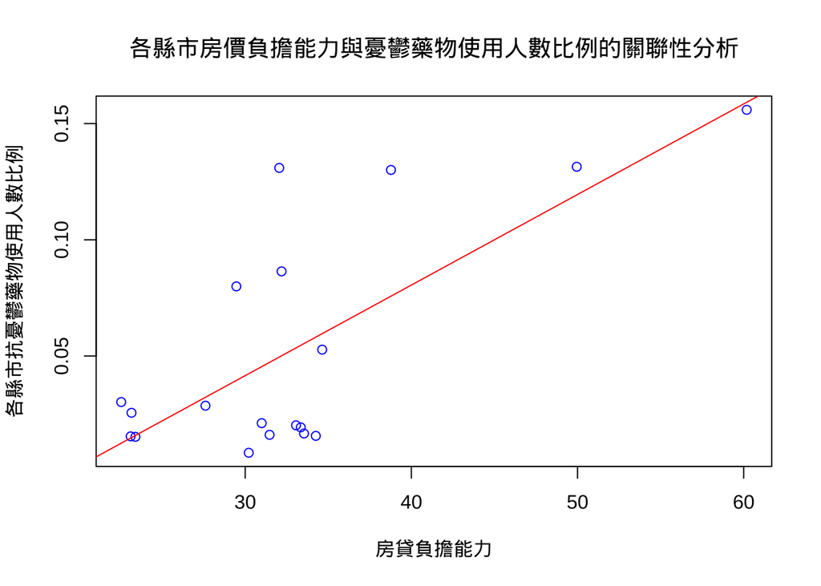

## 伍、參考資料

- 衛生福利部統計處：抗憂鬱藥物使用人數
- 行政院主計總處：消費者物價指數統計
- 內政部不動產資訊平台：房價負擔能力統計
- http://libir.tmu.edu.tw/bitstream/987654321/58223/2/enews_33_biostat.pdf
- https://rpubs.com/skydome20/R-Note4-Plotting_System